# Social Mistreatment and Alcohol Use Problem Trajectories: The Moderating Effects of Brain Network Activations during the Stop Signal Task

## Step 4: Conditional model with growth curves, time-invariant covariates, and time-varying predictor

Now let’s add the time-varying predictor (SocialMis) to the model, but without random slope in the model.

### Level 1

AUDIT<sub>ij</sub> = β<sub>0j</sub> + β<sub>1j</sub>Sex<sub>ij</sub> + β<sub>2j</sub>AdChild<sub>ij</sub> + β<sub>3j</sub>Time<sub>ij</sub> + e<sub>ij</sub>

### Level 2

β<sub>3j</sub> = γ<sub>10</sub> + γ<sub>11</sub>SocialMis<sub>j</sub> + r<sub>2j</sub>

### Mixed model

AUDIT<sub>ij</sub> = β<sub>0j</sub> + β<sub>1j</sub>Sex<sub>ij</sub> + β<sub>2j</sub>AdChild<sub>ij</sub> + (γ<sub>10</sub> + γ<sub>11</sub>SocialMis<sub>j</sub> + r<sub>2j</sub>) * Time<sub>ij</sub> + u<sub>ij</sub>

```r
df_long <- df_long %>% rename(GSM = SocialMis)

socialMis.lme <- lmer(AUDIT ~ 1 + sex + AdChild + GSM*Time + (1 | mriID), data = df_long, REML = FALSE, na.action = na.exclude)
summary(socialMis.lme)
```

```
## Linear mixed model fit by maximum likelihood . t-tests use Satterthwaite's method ['lmerModLmerTest']
## Formula: AUDIT ~ 1 + sex + AdChild + GSM * Time + (1 | mriID)
##    Data: df_long
##
##       AIC       BIC    logLik -2*log(L)  df.resid
##    1799.3    1830.6    -891.6    1783.3       361
##
## Scaled residuals:
##     Min      1Q  Median      3Q     Max
## -2.6160 -0.4568 -0.1502  0.3349  4.1652
##
## Random effects:
##  Groups   Name        Variance Std.Dev.
##  mriID    (Intercept) 4.980    2.231
##  Residual             4.543    2.131
## Number of obs: 369, groups:  mriID, 133
##
## Fixed effects:
##              Estimate Std. Error        df t value Pr(>|t|)
## (Intercept)   2.96572    0.70733 368.99738   4.193 3.45e-05 ***
## sex          -0.11828    0.49928 132.63755  -0.237  0.81311
## AdChild       0.48273    0.26599 147.22278   1.815  0.07159 .
## GSM          -0.05432    0.06433 347.68377  -0.844  0.39902
## Time         -0.42042    0.36650 297.87330  -1.147  0.25225
## GSM:Time      0.12532    0.03838 302.29187   3.265  0.00122 **
## ---
## Signif. codes:  0 '***' 0.001 '**' 0.01 '*' 0.05 '.' 0.1 ' ' 1
##
## Correlation of Fixed Effects:
##          (Intr) sex    AdChld GSM    Time
## sex      -0.224
## AdChild   0.104  0.252
## GSM      -0.900 -0.024 -0.169
## Time     -0.658 -0.018 -0.043  0.692
## GSM:Time  0.595  0.036  0.043 -0.679 -0.954
```

```r
socialMis.coef <- tidy(socialMis.lme, conf.int = TRUE)
socialMis.coef
```

```
## # A tibble: 8 × 10
##   effect   group    term            estimate std.error statistic    df    p.value conf.low conf.high
##   <chr>    <chr>    <chr>              <dbl>     <dbl>     <dbl> <dbl>      <dbl>    <dbl>     <dbl>
## 1 fixed    <NA>     (Intercept)       2.97      0.707      4.19   369.  0.0000345   1.57      4.36
## 2 fixed    <NA>     sex              -0.118     0.499     -0.237  133.  0.813      -1.11      0.869
## 3 fixed    <NA>     AdChild           0.483     0.266      1.81   147.  0.0716     -0.0429    1.01
## 4 fixed    <NA>     GSM              -0.0543    0.0643    -0.844  348.  0.399      -0.181     0.0722
## 5 fixed    <NA>     Time             -0.420     0.366     -1.15   298.  0.252      -1.14      0.301
## 6 fixed    <NA>     GSM:Time          0.125     0.0384     3.27   302.  0.00122     0.0498    0.201
## 7 ran_pars mriID    sd__(Intercept)   2.23     NA         NA       NA  NA          NA        NA
## 8 ran_pars Residual sd__Observation   2.13     NA         NA       NA  NA          NA        NA
```

```r
confint(socialMis.lme)
```

```
## Computing profile confidence intervals ...
```

```
##                   2.5 %     97.5 %
## .sig01       1.87360614 2.64302637
## .sigma       1.95266714 2.33859580
## (Intercept)  1.57028508 4.36120752
## sex         -1.10561372 0.86601561
## AdChild     -0.04093256 1.00899222
## GSM         -0.18111633 0.07290216
## Time        -1.14062263 0.30131151
## GSM:Time     0.04965858 0.20074651
```

```r
print(simple_slopes(socialMis.lme, pred = "Time", mod1 = GSM))
```

```
##         GSM     Time Test Estimate Std. Error       df t value  Pr(>|t|) Sig.
## 1  6.197971   sstest        0.3563     0.1568 283.2312  2.2720 0.0238372    *
## 2   9.45891   sstest        0.7650     0.1109 269.6657  6.8967 3.778e-11  ***
## 3 12.719849   sstest        1.1736     0.1770 291.8259  6.6292 1.629e-10  ***
## 4    sstest 0.075267       -0.0449     0.0624 348.8249 -0.7193 0.4724321
## 5    sstest 1.178862        0.0934     0.0473 348.2676  1.9763 0.0489139    *
## 6    sstest 2.282457        0.2317     0.0645 308.7170  3.5915 0.0003824  ***
```

```r
tiff('interact_plot_time_socialmis.tiff', width = 2000, height = 2000, res = 300)
p <- interact_plot(socialMis.lme, pred = "Time", modx = "GSM", interval = TRUE, modx.labels = c('Low', 'Mean', 'High')) + theme_classic()
print(p)
dev.off()
```

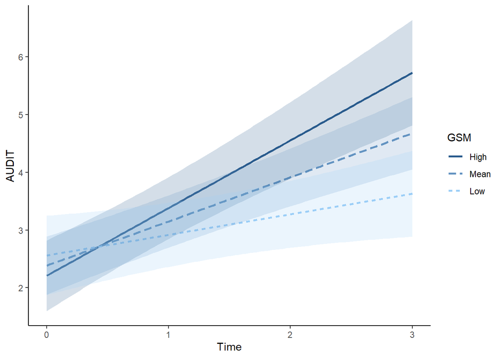

```r
p <- interact_plot(socialMis.lme, pred = "Time", modx = "GSM", interval = TRUE, modx.labels = c('Low', 'Mean', 'High')) + theme_classic()
print(p)
```

```r
# Define GSM values
gsm_mean <- mean(df_long$GSM, na.rm = TRUE)
gsm_sd <- sd(df_long$GSM, na.rm = TRUE)
gsm_levels <- c(gsm_mean - gsm_sd, gsm_mean, gsm_mean + gsm_sd)

# Estimate simple slopes
slopes <- emtrends(
  socialMis.lme,
  var = "Time",
  specs = "GSM",
  at = list(GSM = gsm_levels))

# Pairwise comparisons of slopes
slope_contrasts <- contrast(slopes, method = "pairwise")
summary(slope_contrasts)
```

```
##  contrast                                  estimate    SE  df t.ratio p.value
##  GSM6.19797115661952 - GSM9.45891029810298   -0.409 0.126 307  -3.236  0.0038
##  GSM6.19797115661952 - GSM12.7198494395864   -0.817 0.253 307  -3.236  0.0038
##  GSM9.45891029810298 - GSM12.7198494395864   -0.409 0.126 307  -3.236  0.0038
##
## Results are averaged over the levels of: sex
## Degrees-of-freedom method: kenward-roger
## P value adjustment: tukey method for comparing a family of 3 estimates
```

```r
r.squaredGLMM(socialMis.lme) - r.squaredGLMM(concova.lme)
```

```
##             R2m        R2c
## [1,] 0.02752658 0.02446581
```

```r
anova(concova.lme, socialMis.lme)
```

```
## Data: df_long
## Models:
## concova.lme: AUDIT ~ 1 + sex + AdChild + Time + (1 | mriID)
## socialMis.lme: AUDIT ~ 1 + sex + AdChild + GSM * Time + (1 | mriID)
##               npar    AIC    BIC  logLik -2*log(L)  Chisq Df Pr(>Chisq)
## concova.lme      6 1809.1 1832.6 -898.56    1797.1
## socialMis.lme    8 1799.3 1830.6 -891.64    1783.3 13.832  2  0.0009919 ***
## ---
## Signif. codes:  0 '***' 0.001 '**' 0.01 '*' 0.05 '.' 0.1 ' ' 1
```

```r
df_long <- df_long %>% rename(SocialMis = GSM)
# SocialMis doesn't have a significant main effect on AUDIT, but it interacts with time, as peopel with a greater SocialMis tend to have a greater increase in AUDIT over time.
```

## Step 5: Conditional model with growth curves, time-invariant covariates, time-varying predictor, and random slope

Now let’s make the slope to be random across participants.

```r
randSlope.lme <- lmer(AUDIT ~ 1 + sex + AdChild + SocialMis*Time + (1 + Time | mriID), data = df_long, REML = FALSE, na.action = na.exclude)
summary(randSlope.lme)
```

```
## Linear mixed model fit by maximum likelihood . t-tests use Satterthwaite's method ['lmerModLmerTest']
## Formula: AUDIT ~ 1 + sex + AdChild + SocialMis * Time + (1 + Time | mriID)
##    Data: df_long
##
##       AIC       BIC    logLik -2*log(L)  df.resid
##    1790.2    1829.3    -885.1    1770.2       359
##
## Scaled residuals:
##     Min      1Q  Median      3Q     Max
## -2.7801 -0.4259 -0.1379  0.3254  4.0031
##
## Random effects:
##  Groups   Name        Variance Std.Dev. Corr
##  mriID    (Intercept) 3.9031   1.9756
##           Time        0.4884   0.6988   0.35
##  Residual             3.8152   1.9533
## Number of obs: 369, groups:  mriID, 133
##
## Fixed effects:
##                 Estimate Std. Error        df t value Pr(>|t|)
## (Intercept)      2.77032    0.65772 252.77367   4.212 3.52e-05 ***
## sex             -0.26329    0.48166 132.86405  -0.547   0.5855
## AdChild          0.45949    0.25538 143.99709   1.799   0.0741 .
## SocialMis       -0.03123    0.05996 252.05490  -0.521   0.6029
## Time            -0.12823    0.38447 199.72922  -0.334   0.7391
## SocialMis:Time   0.09912    0.04008 232.24871   2.473   0.0141 *
## ---
## Signif. codes:  0 '***' 0.001 '**' 0.01 '*' 0.05 '.' 0.1 ' ' 1
##
## Correlation of Fixed Effects:
##             (Intr) sex    AdChld SoclMs Time
## sex         -0.232
## AdChild      0.139  0.251
## SocialMis   -0.903 -0.024 -0.210
## Time        -0.610 -0.020 -0.119  0.660
## SocialMs:Tm  0.575  0.028  0.123 -0.655 -0.942
```

```r
randSlope.coef <- tidy(randSlope.lme, conf.int = TRUE)
randSlope.coef
```

```
## # A tibble: 10 × 10
##    effect   group    term                  estimate std.error statistic    df    p.value conf.low conf.high
##    <chr>    <chr>    <chr>                    <dbl>     <dbl>     <dbl> <dbl>      <dbl>    <dbl>     <dbl>
##  1 fixed    <NA>     (Intercept)             2.77      0.658      4.21   253.  0.0000352   1.48      4.07
##  2 fixed    <NA>     sex                    -0.263     0.482     -0.547  133.  0.586      -1.22      0.689
##  3 fixed    <NA>     AdChild                 0.459     0.255      1.80   144.  0.0741     -0.0453    0.964
##  4 fixed    <NA>     SocialMis              -0.0312    0.0600    -0.521  252.  0.603      -0.149     0.0868
##  5 fixed    <NA>     Time                   -0.128     0.384     -0.334  200.  0.739      -0.886     0.630
##  6 fixed    <NA>     SocialMis:Time          0.0991    0.0401     2.47   232.  0.0141      0.0202    0.178
##  7 ran_pars mriID    sd__(Intercept)         1.98     NA         NA       NA  NA          NA        NA
##  8 ran_pars mriID    cor__(Intercept).Time   0.353    NA         NA       NA  NA          NA        NA
##  9 ran_pars mriID    sd__Time                0.699    NA         NA       NA  NA          NA        NA
## 10 ran_pars Residual sd__Observation         1.95     NA         NA       NA  NA          NA        NA
```

```r
# print(simple_slopes(randSlope.lme, pred = "Time", mod1 = SocialMis))
# print(interact_plot(randSlope.lme, pred = "Time", modx = SocialMis, interval = TRUE))

anova(socialMis.lme, randSlope.lme)
```

```
## Data: df_long
## Models:
## socialMis.lme: AUDIT ~ 1 + sex + AdChild + GSM * Time + (1 | mriID)
## randSlope.lme: AUDIT ~ 1 + sex + AdChild + SocialMis * Time + (1 + Time | mriID)
##               npar    AIC    BIC  logLik -2*log(L)  Chisq Df Pr(>Chisq)
## socialMis.lme    8 1799.3 1830.6 -891.64    1783.3
## randSlope.lme   10 1790.2 1829.3 -885.08    1770.2 13.127  2   0.001411 **
## ---
## Signif. codes:  0 '***' 0.001 '**' 0.01 '*' 0.05 '.' 0.1 ' ' 1
```

```r
# Although adding random slope works, we didn't do it in the following models because oflater convergence issues.
```

## Step 6a: Full model

Now let’s add the inhibition-related moderators one by one to the model. This is now a conditional model with growth curves, time-invariant covariates, time-varying predictor, time-invariant inhibition-related moderators, and random intercept.

### Level 1

AUDIT<sub>ij</sub> = β<sub>0j</sub> + β<sub>1j</sub>Sex<sub>ij</sub> + β<sub>2j</sub>AdChild<sub>ij</sub> + β<sub>3j</sub>Time<sub>ij</sub> + e<sub>ij</sub>

### Level 2

β<sub>3j</sub> = γ<sub>10</sub> + γ<sub>11</sub>SocialMis<sub>j</sub> + γ<sub>12</sub>Inhibition<sub>j</sub> + r<sub>2j</sub>

### Mixed model

AUDIT<sub>ij</sub> = β<sub>0j</sub> + β<sub>1j</sub>Sex<sub>ij</sub> + β<sub>2j</sub>AdChild<sub>ij</sub> + (γ<sub>10</sub> + γ<sub>11</sub>SocialMis<sub>j</sub> + γ<sub>12</sub>Inhibition<sub>j</sub> + r<sub>2j</sub>) * Time<sub>ij</sub> + u<sub>ij</sub>